# Final Project - Climate Change

# Predictions

```r
predictedRain <- predict(q10_model, q10_test)
predictedRain
```

[output not shown]

[output cut: 43 more lines]

[output not shown]

# Predictions vs Actuals

```r
q10Prediction <- data.frame(Temp = q10_test$TEMP_AVG,
                            ActualRain = q10_test$RAIN,
                            PredictedRain = predictedRain)
q10Prediction
```

|  | Temp | ActualRain | PredictedRain |
| --- | --- | --- | --- |
| 2 | 32 | 0.10 | 0.19173401 |
| 5 | 15 | 0.28 | 0.09770066 |
| 8 | 11 | 0.02 | 0.08456732 |
| 11 | 14 | 0.14 | 0.09413927 |
| 14 | 34 | 0.10 | 0.20785751 |
| 17 | 31 | 0.01 | 0.18364378 |
| 20 | 34 | 0.02 | 0.20785751 |
| 23 | 32 | 0.02 | 0.19173401 |
| 26 | 31 | 0.08 | 0.18364378 |
| 29 | 30 | 0.15 | 0.17575485 |

[output cut: 618 more lines]

In the above data frame, we see the model predictions vs the actual rain for said temperatures. What is the predicted rain amount in inches if the temperature is 70 degrees?

```r
q10Prediction %>%
  filter(Temp == 70)
```

|  | Temp | ActualRain | PredictedRain |
| --- | --- | --- | --- |
| 104 | 70 | 0.79 | 0.4605531 |
| 125 | 70 | 0.29 | 0.4605531 |
| 350 | 70 | 0.38 | 0.4605531 |
| 479 | 70 | 0.06 | 0.4605531 |
| 500 | 70 | 0.28 | 0.4605531 |
| 629 | 70 | 0.24 | 0.4605531 |
| 644 | 70 | 1.68 | 0.4605531 |
| 1043 | 70 | 0.01 | 0.4605531 |
| 1115 | 70 | 1.96 | 0.4605531 |
| 1199 | 70 | 0.01 | 0.4605531 |

[output cut: 5 more lines]

The model predicts the rain to be 0.46 inches.

# Scatter - Predicted vs Actual

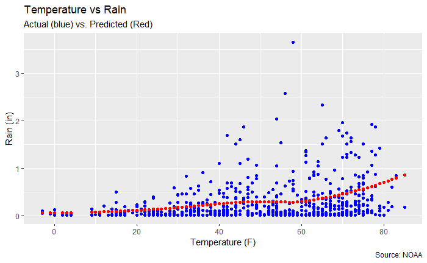

```r
ggplot(q10Prediction, aes(x = Temp)) +
  geom_point(aes(y = ActualRain), color = "blue") +
  geom_point(aes(y = PredictedRain), color = "red") +
  labs(title = "Temperature vs Rain",
       subtitle = "Actual (blue) vs. Predicted (Red)",
       y = "Rain (in)",
       x = "Temperature (F)",
       caption = "Source: NOAA")
```

The higher the temperature, the more the model predicts rain to be.

# Mean Absolute Error

```r
q10_mae <- MAE(q10Prediction$ActualRain, q10Prediction$PredictedRain)
cat("Mean Absolute Error:", q10_mae)
```

```
Mean Absolute Error: 0.2752324
```

# Root Mean Squared Error

```r
install.packages("caret")
q10_rmse <- RMSE(q10Prediction$ActualRain, q10Prediction$PredictedRain)
cat("Root Mean Squared Error:", q10_rmse)
```

```
Root Mean Squared Error: 0.4060287
```

# Mean Squared Error

```r
q10_mse <- q10_rmse*q10_rmse
cat("Mean Squared Error:", q10_mse)
```

```
Mean Squared Error: 0.1648593
```

R2: Since this is a loess model, there is no R2 value. R2 is for linear models.

# Time Series - July 2020 vs July 2023

How much higher or lower is the July 2023 temperature forecast in comparison with July 2020?

# Subset the Data

```r
q8_data <- data_final %>%
  filter(COUNTY == "Miami Dade", !is.na(TEMP_AVG), TEMP_AVG > 0) %>%
  select(DATE, TEMP_AVG) %>%
  group_by(DATE) %>%
  summarize(meanT = mean(TEMP_AVG)) %>%
 mutate(MONTH = month(DATE, label = TRUE),
         YEAR = year(DATE)) %>%
 group_by(MONTH, YEAR) %>%
 summarize(meanT = mean(meanT)) %>%
  arrange(YEAR, MONTH)
q8_data
```

| MONTH | YEAR | meanT |
| --- | --- | --- |
| Mar | 1992 | 68.70000 |
| Apr | 1992 | 71.76667 |
| May | 1992 | 76.32258 |
| Jun | 1992 | 80.03333 |
| Jul | 1992 | 86.12903 |
| Aug | 1992 | 85.08696 |
| Oct | 1992 | 72.12500 |
| Nov | 1992 | 74.46667 |
| Dec | 1992 | 68.32258 |
| Jan | 1993 | 71.16129 |

[output cut: 332 more lines]

# Decomposition

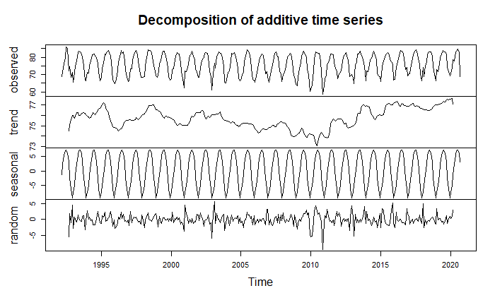

```r
q8TS <- ts(q8_data$meanT, start = c(1992, 3), end = c(2020, 9), frequency = 12)
q8Decomp <- decompose(q8TS)
plot(q8Decomp)
```

# Arima Model

```r
arimaModel <- auto.arima(q8TS)
arimaFcst <- forecast(arimaModel, h = 36)
arimaFcst
```

|  | Point Forecast | Lo 80 | Hi 80 | Lo 95 | Hi 95 |
| --- | --- | --- | --- | --- | --- |
| Oct 2020 | 71.77916 | 68.70282 | 74.85550 | 67.07431 | 76.48401 |
| Nov 2020 | 69.94360 | 66.77828 | 73.10892 | 65.10266 | 74.78454 |
| Dec 2020 | 67.27465 | 64.10359 | 70.44572 | 62.42493 | 72.12438 |
| Jan 2021 | 72.25742 | 69.08600 | 75.42883 | 67.40715 | 77.10768 |
| Feb 2021 | 71.94701 | 68.77557 | 75.11845 | 67.09671 | 76.79731 |
| Mar 2021 | 76.95668 | 73.78524 | 80.12812 | 72.10638 | 81.80698 |
| Apr 2021 | 78.60996 | 75.43852 | 81.78141 | 73.75966 | 83.46027 |
| May 2021 | 82.25968 | 79.08823 | 85.43112 | 77.40937 | 87.10998 |
| Jun 2021 | 83.56819 | 80.39674 | 86.73963 | 78.71788 | 88.41849 |
| Jul 2021 | 83.67784 | 80.50640 | 86.84928 | 78.82754 | 88.52814 |

[output cut: 26 more lines]

The forecasted temperature in July 2023 is 84 degrees F, with a 95% confidence interval range of 78.1 to 89.9.

# Forecast Plot

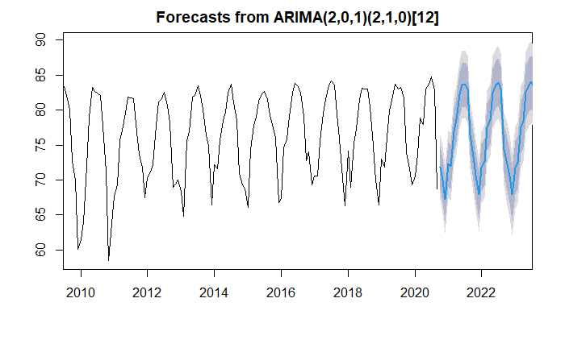

```r
plot(arimaFcst, xlim = c(2010, 2023))
```

Due to the volatility of the data, the error for our forecast are wide even with near term predictions.

# July 2020 Temperature

```r
q8_data %>%
  filter(MONTH == "Jul", YEAR == 2020) %>%
  select(meanT)
```

| MONTH | meanT |
| --- | --- |
| Jul | 83.65591 |

The temperature in July 2020 in Miami Dade is 83.66 F. Therefore, temperatures for July are expected to me 0.34 degrees higher by 2023.

# Time Series - Florida Rain Forecast

How much rain is forecasted for Florida over the next year?

# Subset the Data

```r
q9_data <- data_final %>%
  filter(STATE == "Florida", !is.na(RAIN), RAIN > 0) %>%
  select(DATE, RAIN) %>%
  group_by(DATE) %>%
  summarize(meanR = mean(RAIN)) %>%
 mutate(MONTH = month(DATE, label = TRUE),
         YEAR = year(DATE)) %>%
 group_by(MONTH, YEAR) %>%
 summarize(meanR = mean(meanR)) %>%
  arrange(YEAR, MONTH)
q9_data
```

| MONTH | YEAR | meanR |
| --- | --- | --- |
| Jan | 1980 | 0.28362222 |
| Feb | 1980 | 0.15667857 |
| Mar | 1980 | 0.55152778 |
| Apr | 1980 | 0.61598655 |
| May | 1980 | 0.25818506 |
| Jun | 1980 | 0.47820857 |
| Jul | 1980 | 0.40263232 |
| Aug | 1980 | 0.43083479 |
| Sep | 1980 | 0.30232716 |
| Oct | 1980 | 0.44506267 |

[output cut: 479 more lines]

# Decomposition

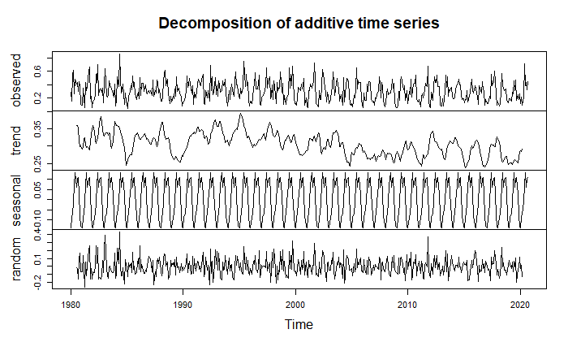

```r
q9TS <- ts(q9_data$meanR, start = c(1980, 1), end = c(2020, 9), frequency = 12)
q9Decomp <- decompose(q9TS)
plot(q9Decomp)
```

# Arima Model

```r
arimaModel2 <- auto.arima(q9TS)
arimaFcst2 <- forecast(arimaModel2, h = 12)
arimaFcst2
```

|  | Point Forecast | Lo 80 | Hi 80 | Lo 95 | Hi 95 |
| --- | --- | --- | --- | --- | --- |
| Oct 2020 | 0.2400961 | 0.08014648 | 0.4000457 | -0.004525724 | 0.4847179 |
| Nov 2020 | 0.2247333 | 0.06330724 | 0.3861593 | -0.022146548 | 0.4716131 |
| Dec 2020 | 0.2008597 | 0.03855086 | 0.3631685 | -0.047370243 | 0.4490896 |
| Jan 2021 | 0.2244680 | 0.06199212 | 0.3869438 | -0.024017387 | 0.4729533 |
| Feb 2021 | 0.2295683 | 0.06595831 | 0.3931782 | -0.020651559 | 0.4797881 |
| Mar 2021 | 0.2552351 | 0.08649828 | 0.4239718 | -0.002825574 | 0.5132957 |
| Apr 2021 | 0.3060520 | 0.13408963 | 0.4780144 | 0.043058247 | 0.5690458 |
| May 2021 | 0.3220938 | 0.14851602 | 0.4956716 | 0.056629503 | 0.5875581 |
| Jun 2021 | 0.3665838 | 0.19274119 | 0.5404263 | 0.100714487 | 0.6324530 |
| Jul 2021 | 0.3393226 | 0.16545664 | 0.5131885 | 0.073417582 | 0.6052275 |

[output cut: 2 more lines]

# Forecast

```r
arima2_values <- c(0.2400961, 0.2247333, 0.2008597, 0.2244680, 0.2295683, 0.2552351, 0.3060520, 0.3220938, 0.3665838, 0.3393226, 0.3596949, 0.2874200)
cat("Over the next year, the average monthly rainfall is expected to be:", mean(arima2_values), "inches")
```

```
Over the next year, the average monthly rainfall is expected to be: 0.2796773 inches
```

# Forecast Plot

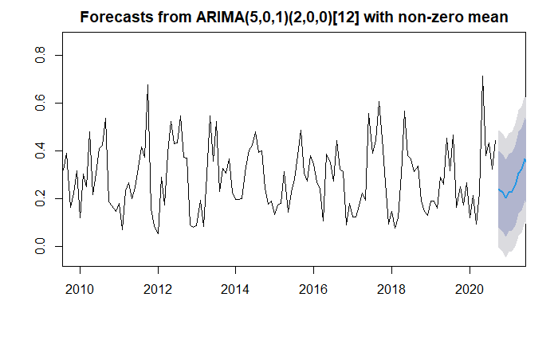

```r
plot(arimaFcst2, xlim = c(2010, 2021))
```

The next year’s rainfall forecasts have a big error margin due to the randomness of the data.